# Introduction to R Markdown

## Citing your sources and adding graphics

### Graphics from external links

You can add graphics from the internet, using external links. For this you need a function from `knitr package` (which will modify the document at the knitting phase).

```r
# you may consider the echo option for this chunk, so that only the plot is shown
knitr::include_graphics("https://imgs.xkcd.com/comics/machine_learning.png")
```

[output not shown]

### Graphics from working directory

You can also include images from your working directory. In order to do it you need to put the syntax `![alternative text for your image](source/of/the/file.png)`. The path here can be absolute or relative to your working directory.

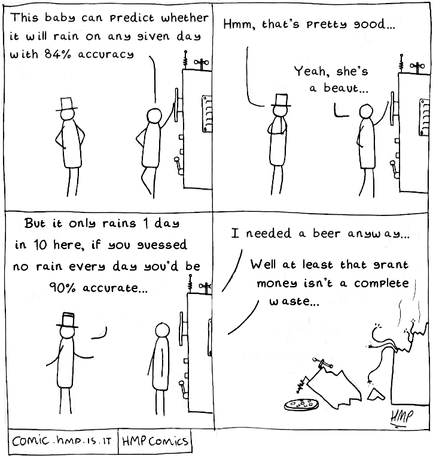

Picture from working directory

The same can be done with the `knitr` package

```r
# additional options set here: eval=FALSE, fig.cap="This is my plot", out.width = '20%'
knitr::include_graphics("graphics/datascience.png")
```

### Interactive links

You can also include **links**. In order to do it you need to put `[under which words the link will be active](www.theActualLinkToYourResource.com)`. For example [here](https://rmarkdown.rstudio.com/lesson-1.html) you can find the RStudio documentation for R Markdown.

### Footnotes

Citing other resources can be done in the **footnotes**. This can be helpful for citing literature or just providing additonal information about certain topic. Footnotes are created as follows:

- write the text for which the footnote will be added
- add `[^1]` sign after your text like so[^1]
- then at the very end of your R Markdown document add the content of your footnote in the following way: `[^1]: This was my first footnote`
- add more footnotes if needed[^2]

## More resources

> You can learn much more about R Markdown [here](https://bookdown.org/yihui/rmarkdown-cookbook/)

You can explore the *visual markdown editor*

[figure not shown]

Interactive editor

## Tasks

1. Create your own R Markdown report with html output. Make sure it is organised in sections and it includes text formatting and external graphics. Tip: you can try to reproduce some elements from a Wikipedia page of your choice.
2. Extend the report with some exemplary code. Use any dataset that is already loaded in R (iris, cars, etc.) and create a linear model. Show statistics of chosen variables and generate some plots. Make sure to play around with different chunk options.
3. Learn how to add a floating menu and a different theme to your final html report. Tip: Stack Overflow knows all the answers. Learn the possible options and experiment with it.
4. Add bibliography to your document. Make sure to include a link and a proper citation.
5. Experiment with the “visual markdown editor”. See how it can help you with easier R Markdown editing.
6. Learn why “escape characters” are so important, especially when using plain text editing.
[^1]: My first footnote.
[^2]: Following footnotes should have consecutive numbers.